# Analysis of Circumcision Data

Author

Ramon + Sean

Published

February 12, 2024

```r
library(tidyverse)
library(DT)
```

# Overview + Highlights

In this sort of analysis, our expectation would be that shaft samples look the same between circumcised and uncircumcised individuals, and that the glans samples react to virus differently and/or have different resident immune cell populations.

## Bigger Plots

## Specific Insights

## Remaining Questions/Concerns

## Conclusions + Future Analysis

# In Depth Analysis

## Virion Particle count

## Mast Cell Count Analysis

## Immunofluorescence Cell Distribution

We also had data from an immunofluorescence experiment, in which these samples of glans/shaft had been stained with CD3, CD4, and CCR10. Approximate cell types based on these markers are delineated below:

```r
tribble(
  ~ "IF Expression", ~ "Expected Cell Type",
  "CD3+CD4+CCR10+", "Th22 (Tissue Homing T cell)",
  "CD3+CCR10+", "CD8+ Cutaneous Lymphoid Antigen T cell",
  "CD4+CCR10+", "Langerhans skin cell",
  "CD3+CD4+", "CD4+ T cell (likely Th1, Th2, Th9, or Th17)",
  "CD3+", "Other T cell",
  "CD4+", "HIV susceptible innate immune cells (macrophages, mast cells, etc)",
  "CCR10+", "Melanocytes"
) |>
  gt::gt() |>
  gt::tab_header(title = "Expected IF Cell Types")
```

Expected IF Cell Types

| IF Expression | Expected Cell Type |
| --- | --- |
| CD3+CD4+CCR10+ | Th22 (Tissue Homing T cell) |
| CD3+CCR10+ | CD8+ Cutaneous Lymphoid Antigen T cell |
| CD4+CCR10+ | Langerhans skin cell |
| CD3+CD4+ | CD4+ T cell (likely Th1, Th2, Th9, or Th17) |
| CD3+ | Other T cell |
| CD4+ | HIV susceptible innate immune cells (macrophages, mast cells, etc) |
| CCR10+ | Melanocytes |

Here, looking at the number of cells per sample isn’t the most interesting, as this is likely just a result of how the tissue was cut. What *would* be interesting would be to look at if the *distribution*, i.e. how far any particular cell type was from the beginning of the epithelial layer, of these cells changed as a result of the virion infection.

### Adding Back virion penetration data

We can also then go back to correlate this with virion penetration data:

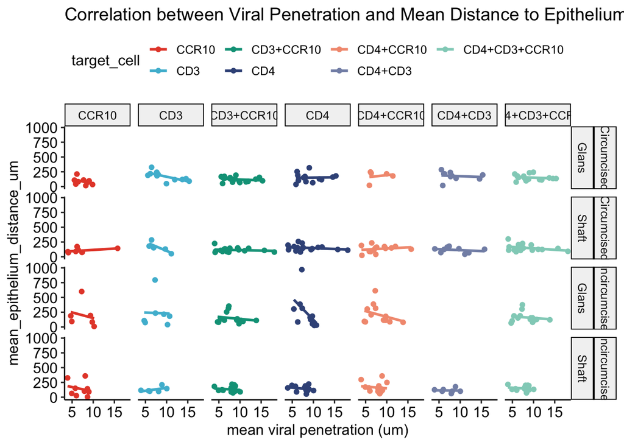

```r
load(file = "figures/plots/correlation_plot_1.rda")

correlation_plot_1
```

Here, we can also zoom in on the tip of the biopsy– as the plot above shows, virions aren’t really penetrating further than 20um. If we just zoom into this area, we can see what % of each cell type is within our “viral range” (here defined as 30um from the epithelium), both in the case where virus was present (4h) and was not (Non infected). *Does the presence of virions affect the % of immune cell types at the tip?*

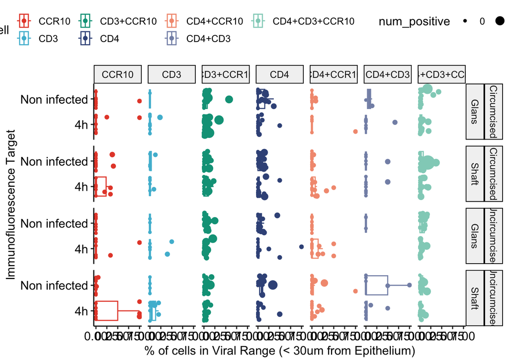

```r
load(file = "figures/plots/correlation_plot_2.rda")

correlation_plot_2
```

Probably not. Maybe something weird (again) happening with the CD4 single positive cells; not sure how relevant this is though and may just reflect a subset of these cells that we don’t have markers to define.